# R Notebook

# General imports

```r
library(jsonlite)
library(tidyverse)
library(ggthemes)
library(lme4)
library(lmerTest)
library(tidyboot)
library(coda)
library(irr)
estimate_mode <- function(s) {
  d <- density(s)
  return(d$x[which.max(d$y)])
}
HPDhi<- function(s){
  m <- HPDinterval(mcmc(s))
  return(m["var1","upper"])
}
HPDlo<- function(s){
  m <- HPDinterval(mcmc(s))
  return(m["var1","lower"])
}
```

# Experiment 1

## Setup data

### Import turk survey data

```r
exp1_subjInfo <- read_csv('../data/final/experiment1/planned_sample/turk/subjInfo.csv')
```

### Import message data and implement preregistered exclusions

```r
d_annotated <- read_csv('../data/final/experiment1/planned_sample/chatMessage/messages_with_annotations.csv')
# nonNativeSpeakerIDs <- unique((tangramSubjInfo %>% filter(nativeEnglish != "yes"))$gameid)
incompleteIDs <- unique((d_annotated %>% group_by(gameid) %>%
                           filter(length(unique(trialNum)) != 24))$gameid)
confused <- unique((exp1_subjInfo %>% filter(understandsInstructions != 'yes'))$gameid)
nonNative <- unique((exp1_subjInfo %>% filter(nativeEnglish != 'yes'))$gameid)
# Some speakers violated instructions by relying fully on location in grid
location_abusers <- c('8219-bb7861c1-43f4-480c-906b-8441c583c0ab',
                      '7726-3d4a266f-e56d-4afb-9a79-b40deb690a76',
                      '5684-f09de856-4d64-423c-b342-b30e7325eb0e',
                      '7600-346d56b5-bd76-406f-befb-6b47e07d5916')
# Some speakers violated instructions by playing this weird taboo game where they gave riddles
tabooers <- c('2929-d218f724-b45e-416b-af44-5cab5658bad9', #(opposite of white... primary color...)
              '7600-346d56b5-bd76-406f-befb-6b47e07d5916', # MERRY GO ROUND
              '3462-7e95c955-4087-4eb9-bbc8-05338f9a5e4b') # CAN YOU SEE???
badGames <- c(incompleteIDs, nonNative, location_abusers, confused, tabooers)
d <- d_annotated %>%
  mutate(numFeatures = colorMention + shapeMention + textureMention) %>%
  filter(!(gameid %in% badGames)) %>%
  mutate(occlusions = as.factor(occlusions),
        context = as.factor(context))
```

How many recruited, how many excluded, for what reasons, etc?

```r
paste0('recruited ', length(exp1_subjInfo$gameid))
```

```
[1] "recruited 187"
```

```r
paste0('total games ', length(unique(d_annotated$gameid)))
```

```
[1] "total games 102"
```

```r
paste0('incomplete ', length(incompleteIDs))
```

```
[1] "incomplete 7"
```

```r
paste0('confused ', length(setdiff(confused,incompleteIDs)))
```

```
[1] "confused 5"
```

```r
paste0('non-native english ', length(setdiff(nonNative, union(confused, incompleteIDs))))
```

```
[1] "non-native english 1"
```

```r
paste0('violated instructions ', length(setdiff(c(location_abusers, tabooers), union(nonNative, union(confused, incompleteIDs)))))
```

```
[1] "violated instructions 6"
```

```r
paste0('final sample ', length(unique(d$gameid)))
```

```
[1] "final sample 83"
```

### Import click data

```r
exp1_clicks <- read_tsv('../data/final/experiment1/planned_sample/clickedObj/clickedObj.csv') %>%
  mutate(correct = ifelse(correct == 'true', 1, 0)) %>%
  filter(!(gameid %in% badGames))
```

### Write out for modeling & bayesian data analysis

Add missing column annotating whether critical distractor in close trials different from target in texture, color, or both…

```r
bdaInput = exp1_clicks %>%
  mutate(names = substr(names,2,nchar(names)-1)) %>%
  separate(names, sep = ',', into = c('item1','item2','item3', 'item4', 'item5'),
           extra = "merge", fill = "left") %>%
  select(-item5) %>%
  gather(distractorNum, distractorName, item1:item4) %>%
  separate(intendedName, into = c('targetTexture', 'targetColor', 'targetShape')) %>%
  filter(!is.na(distractorName)) %>%
  separate(distractorName, into = c('distractorTexture', 'distractorColor', 'distractorShape')) %>%
  filter(distractorShape == targetShape) %>%
  mutate(textureMatch = distractorTexture == targetTexture) %>%
  mutate(colorMatch = distractorColor == targetColor) %>%
  mutate(distractorType = ifelse(textureMatch, 'texture_shape', ifelse(colorMatch, 'color_shape', 'shape_only'))) %>%
  select(gameid, trialNum, distractorType) %>%
  right_join(exp1_clicks) %>%
  mutate(distractorType = ifelse(is.na(distractorType), 'diff_shape', distractorType)) %>%
  right_join(d)

write_csv(bdaInput %>% select(gameid, trialNum, distractorType, context, hidden,
                              numDistractors, colorMention, shapeMention, textureMention),
  '../modeling/bdaInput/bdaInput.csv')
```

## Speaker results

### Visualize message length collapsing across all subjects

```r
dodge <- position_dodge(width=0.9)
cbPalette = c(rgb(0.8, .8, .8), rgb(.8, .3, .3),  rgb(0, .6, .4), rgb(.4, .4, .4))

d %>%
  group_by(context, hidden) %>%
  tidyboot_mean(column = numRawWords) %>%
  ggplot(aes(x = context, y = empirical_stat, fill = hidden)) +
    geom_bar(stat = 'identity', position = dodge) +
    geom_errorbar(aes(ymin = ci_lower, ymax = ci_upper), position = dodge, width = 0) +
    theme_few() +
    theme(aspect.ratio = 1, text = element_text(size=20)) +
    scale_fill_manual(values=cbPalette) +
    ylab('mean # words')

ggsave('../../pragmatics_of_perspective_taking_tex/pnas_format/figures/num_words.pdf', width = 4, height = 3)
```

### Full mixed-model for effects of condition

```r
contrasts(d$context) <- contr.treatment(2, base = 2)
contrasts(d$occlusions) <- contr.treatment(2, base = 2)

summary(lmer(numRawWords ~ context * occlusions + (1 + context * occlusions | gameid), data = d ))
```

### Use feature data instead

```r
d.booted <- d %>%
  gather(feature, mentioned, shapeMention, colorMention, textureMention) %>%
  group_by(context, hidden, feature) %>%
  tidyboot_mean(column = mentioned)

d.booted %>%
  mutate(feature = factor(feature, levels = c('shapeMention', 'colorMention', 'textureMention'))) %>%
  ggplot(aes(x = context, y = mean, fill = hidden)) +
    geom_bar(stat = 'identity', position = dodge) +
    geom_errorbar(aes(ymax = ci_upper, ymin = ci_lower), position = dodge, width = 0) +
    facet_wrap(~ feature) +
    theme_few() +
    theme(aspect.ratio = 1, text = element_text(size=20))  +
    ylab('% utterances with feature') +
    scale_fill_manual(values=cbPalette)

ggsave('../../pragmatics_of_perspective_taking_tex/pnas_format/figures/by-feature-analysis.pdf',
       height = 3, width = 9)
```

Note: Random interaction doesn’t converge for full model (less variance in these numbers…)

```r
contrasts(d$context) <- contr.treatment(2, base = 2)
contrasts(d$occlusions) <- contr.treatment(2, base = 2)
summary(glmer(colorMention ~ occlusions * context + (1 + occlusions | gameid),
              family = 'binomial', data = d))
```

```r
summary(glmer(textureMention ~ occlusions * context + (1 + occlusions | gameid),
              family = 'binomial', data = d))
```

## Listener analyses

### How common are errors?

```r
## Errors by condition
numErrorsByCondition <- exp1_clicks %>%
  group_by(context, occlusions) %>%
  summarize(totalCorrect = sum(correct), totalErrors = length(correct) - totalCorrect)
```

[output not shown]

## Model-based analyses

Look at pattern of predictives for each model, compared to empirical number of features mentioned

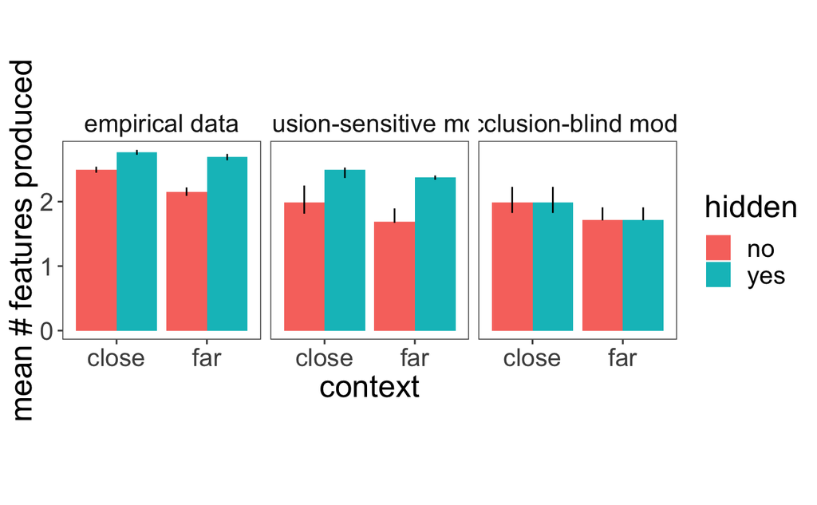

```r
rbind(
    read.csv('../modeling/bdaOutput/occlusionSensitivityPredictives.csv') %>% mutate(source = 'occlusion-sensitive model'),
    read.csv('../modeling/bdaOutput/egocentricPredictives.csv') %>% mutate(source = 'occlusion-blind model')
    ) %>%
  mutate(i = row_number()) %>%
  gather(condition, value, -prob, -MCMCprob, -source, -i) %>%
  separate(condition, sep = '_', into = c('context', 'numDistractors', 'distractorType', 'hidden')) %>%
  group_by(context, hidden, source) %>%
  summarize(mean = estimate_mode(value),
            ci_lower = round(HPDlo(value), 3),
            ci_upper = round(HPDhi(value), 3)) %>%
  #separate(condition, into = c('context', 'hidden')) %>%
  ungroup() %>%
  mutate(hidden = ifelse(hidden == 'hidden', 'yes', 'no')) %>%
  rbind(d %>%
          group_by(context, hidden) %>%
          tidyboot_mean(column = numFeatures) %>%
          ungroup() %>%
          mutate(context = as.character(context)) %>%
          mutate(source = as.character('empirical data')) %>%
          select(-empirical_stat, -n)) %>%
  mutate(source = factor(source, levels = c('empirical data', 'occlusion-sensitive model',
                                            'occlusion-blind model'))) %>%
  ggplot(aes(x = context, fill = hidden, y = mean)) +
    geom_bar(stat = 'identity', position = dodge) +
    geom_errorbar(aes(ymax = ci_upper, ymin = ci_lower), position = dodge, width = 0) +
    facet_wrap(~ source) +
    theme_few() +
    theme(aspect.ratio = 1, text = element_text(size=20)) +
    ylab('mean # features produced')
```

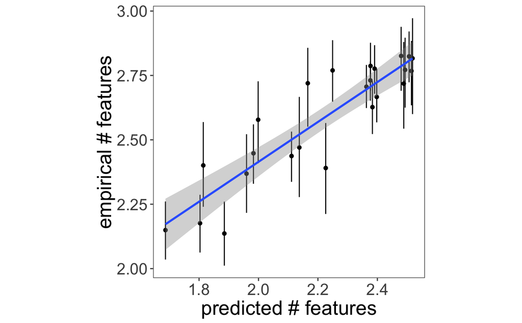

```r
to.plot <- rbind(read.csv('../modeling/bdaOutput/occlusionSensitivityPredictives.csv') %>% mutate(source = 'occlusion-sensitive model'),
     read.csv('../modeling/bdaOutput/egocentricPredictives.csv') %>% mutate(source = 'occlusion-blind model')
     ) %>%
  mutate(i = row_number()) %>%
  gather(condition, value, -prob, -MCMCprob, -source, -i) %>%
  group_by(condition, source) %>%
  summarize(mean = estimate_mode(value),
            ci_lower = round(HPDlo(value), 3),
            ci_upper = round(HPDhi(value), 3)) %>%
  separate(condition, sep = '_', into = c('context', 'numDistractors', 'distractorType', 'hidden')) %>%
  mutate(hidden = ifelse(hidden == 'hidden', 'yes', 'no')) %>%
  rbind(read_csv('../modeling/bdaInput/bdaInput.csv') %>%
          mutate(numFeatures = color + shape + texture) %>%
          group_by(context, distractorType, numDistractors, hidden) %>%
          tidyboot_mean(column = numFeatures) %>%
          ungroup() %>%
          mutate(numDistractors = numDistractors - 2) %>%
          mutate(context = as.character(context)) %>%
          mutate(distractorType = gsub("_", "", distractorType)) %>%
          mutate(source = as.character('empirical data')) %>%
          ungroup() %>%
          select(-empirical_stat, -n)) %>%
  mutate(source = factor(source, levels = c('empirical data', 'occlusion-sensitive model',
                                            'occlusion-blind model'))) %>%
  unite(col = asdf, mean, ci_lower, ci_upper) %>%
  spread(source, asdf) %>%
  separate(`empirical data`, sep = '_', into = c('emp_mean', 'emp_lower', 'emp_upper'))%>%
  separate(`occlusion-sensitive model`, sep = '_', into = c('occ_mean', 'occ_lower', 'occ_upper')) %>%
  separate(`occlusion-blind model`, sep = '_', into = c('ego_mean', 'ego_lower', 'ego_upper')) %>%
  mutate(emp_mean = as.numeric(emp_mean), emp_lower = as.numeric(emp_lower), emp_upper = as.numeric(emp_upper),
         occ_mean = as.numeric(occ_mean), occ_lower = as.numeric(occ_lower), occ_upper = as.numeric(occ_upper),
         ego_mean = as.numeric(ego_mean), ego_lower = as.numeric(ego_lower), ego_upper = as.numeric(ego_upper))
ggplot(to.plot, aes(x = occ_mean, y = emp_mean)) +
  geom_point() +#(stat = 'identity', position = dodge) +
  geom_errorbar(aes(ymin = emp_lower, ymax = emp_upper), width = 0) +
  #geom_errorbarh(aes(xmin = occ_lower, xmax = occ_upper), width = 0) +
  geom_smooth(method = 'lm') +
  theme_few() +
  theme(aspect.ratio = 1, text = element_text(size=20)) +
  xlab('predicted # features')+
  ylab('empirical # features')
ggsave('../../pragmatics_of_perspective_taking_tex/cognition_format/figures/predictiveScatter.pdf',
       useDingbats=FALSE )
```

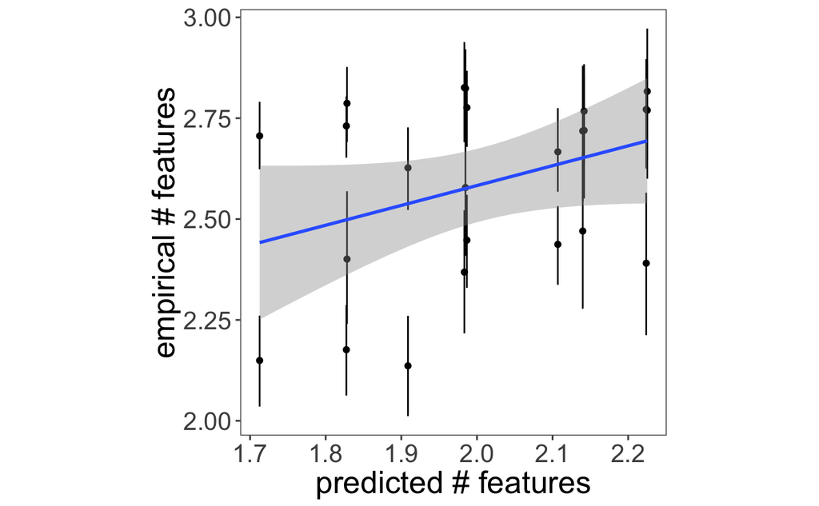

```r
ggplot(to.plot, aes(x = ego_mean, y = emp_mean)) +
  geom_point() +#(stat = 'identity', position = dodge) +
  geom_errorbar(aes(ymin = emp_lower, ymax = emp_upper), width = 0) +
  #geom_errorbarh(aes(xmin = ego_lower, xmax = ego_upper), width = 0) +
  geom_smooth(method = 'lm') +
  theme_few() +
  theme(aspect.ratio = 1, text = element_text(size=20)) +
  xlab('predicted # features')+
  ylab('empirical # features')
ggsave('../../pragmatics_of_perspective_taking_tex/cognition_format/figures/egocentricScatter.pdf',
       useDingbats=FALSE)
```

```r
       #height = 5, width = 9)
```

Get MAP estimates and CIs from param posteriors for occlusion-sensitive model

| parameter | mode | md_lo | md_hi |
| --- | --- | --- | --- |
| alpha | 2.412679e+01 | 2.107141e+01 | 2.593857e+01 |
| colorCost | 1.436128e-04 | 7.282568e-05 | 3.094353e-04 |
| shapeCost | 5.565959e-05 | 5.545385e-05 | 5.545385e-05 |
| textureCost | 6.722581e-03 | 3.374475e-03 | 1.180017e-02 |

Visualize param posteriors

```r
numSamples = 5000
params.samples <- params[rep(row.names(params), exp(params$prob)*numSamples), ] %>%
    gather(parameter, value, alpha:shapeCost)

answererParamPosteriors = ggplot(params.samples, aes(x=log(value)))+
    geom_density(aes(y=..density..),
                 data =subset(params.samples, parameter == "alpha" ),
                 adjust = 3, alpha=.2, fill="#FF6666")+
    geom_density(aes(y=..density..),
                 data=subset(params.samples, parameter == "textureCost"),
                 adjust = 3, alpha=.2, fill="#FF6666")+
    geom_density(aes(y=..density..),
                 data=subset(params.samples, parameter == "colorCost"),
                 adjust = 3, alpha=.2, fill="#FF6666")+
    geom_density(aes(y=..density..),
                 data=subset(params.samples, parameter == "shapeCost"),
                 adjust = 3, alpha=.2, fill="#FF6666")+
    xlab('log parameter value')+
    ggtitle("Parameter Posteriors (5000 samples)") +
    facet_grid(parameter ~ . , scales = 'free') +
    theme_few()

answererParamPosteriors
ggsave('../../pragmatics_of_perspective_taking_tex/pnas_format/appendix/figures/paramPosterior.pdf',
       height = 4, width = 6)
```

log-likelihood plot

```r
rbind(read.csv('../modeling/bdaOutput/occlusionSensitivityParams.csv'),
      read.csv('../modeling/bdaOutput/egocentricParams.csv')) %>%
  group_by(source) %>%
  summarize(maxLikelihood = max(logLikelihood)) %>%
  ggplot(aes(x = source, y = maxLikelihood)) +
    geom_bar(stat = 'identity') +
    theme_few() +
    coord_cartesian(ylim=c(0, -4000)) +
    theme(aspect.ratio = 3)

ggsave("../../pragmatics_of_perspective_taking_tex/pnas_format/appendix/figures/likelihoodPlot.pdf",
       height = 6, width = 2)
```

## Additional checks & exploratory analyses:

### check if speaker results differ across what the distractor is?

```r
bdaInput %>%
  group_by(distractorType, hidden) %>%
  tidyboot_mean(column = numFeatures) %>%
  ggplot(aes(x = distractorType, y = mean, fill = hidden)) +
    geom_bar(stat = 'identity', position = dodge) +
    geom_errorbar(aes(ymax = ci_upper, ymin = ci_lower), position = dodge, width = 0)
```

### check if speaker results depend on number of distractors?

```r
bdaInput %>%
  mutate(numVisible= numDistractors - numObjsOccluded) %>%
  group_by(numVisible, hidden) %>%
  tidyboot_mean(column = numFeatures) %>%
  ggplot(aes(x = numVisible, y = mean, fill = hidden)) +
    geom_bar(stat = 'identity', position = dodge) +
    geom_errorbar(aes(ymax = ci_upper, ymin = ci_lower), position = dodge, width = 0)
```

### Visualize basic (no-hidden) pragmatic effect

```r
basic.d <- d %>%
  filter(hidden == 'no') %>%
  group_by(gameid, context) %>%
  summarize(m = mean(numRawWords)) %>%
  spread(context, m) %>%
  mutate(diff = close- far,
         ratio = log(close / far))

ggplot(basic.d, aes(x = far, y = close)) +
    geom_point() +
    theme_bw() +
    geom_abline(intercept = 0, slope = 1) +
    ylim(1,12) +
    xlim(1,12) +
    theme(aspect.ratio = 1, text = element_text(size=20))
```

Aggregated to difference scores:

```r
tidyboot_mean(basic.d %>%ungroup(), column = diff) %>%
  ggplot(aes(x = 'close - far', y = empirical_stat)) +
      geom_bar(stat ='identity', width = 0.25) +
      geom_errorbar(aes(ymax = ci_upper, ymin = ci_lower), width = 0) +
      theme_few()+
      geom_hline(yintercept = 0) +
      #geom_vline(xintercept = 0) +
      ylim(-1,1) +
      # xlim(-4,4) +
      ylab('# words used') +
    theme(aspect.ratio = 1, text = element_text(size=20))

t.test(basic.d$diff)
```

### Visualize individual differences in num features

Some people used exactly the same number of words on every trial…

```r
hidden.d <- d %>%
  group_by(gameid, context, hidden) %>%
  summarize(m = mean(numFeatures)) %>%
  spread(hidden, m) %>%
  mutate(diff = yes- no,
         ratio = log(yes/no))
```

```r
ggplot(hidden.d, aes(x = no, y = yes)) +
    geom_density_2d() +
    facet_wrap(~ context) +
    theme_bw() +
    geom_abline(intercept = 0, slope = 1) +
    ylim(0,3) +
    ylab('# words (with occlusions)') +
    xlab('# words (without occlusions)') +
    #ggtitle('Within-pair comparisons of reference w/ and w/out occlusion') +
    xlim(0,3) +
    theme(aspect.ratio = 1, text = element_text(size=20))
```

Histogram

```r
hidden.d %>%
  #filter(!(gameid %in% all_the_things_ers)) %>%
  group_by(context) %>%
  mutate(m = mean(diff)) %>%
  ggplot(aes(x = diff)) +
      geom_histogram(binwidth = 0.33) +
      theme_bw() +
      geom_vline(xintercept = 0, linetype = 2) +
      geom_vline(aes(xintercept = m), color = 'red') +
      facet_wrap(~ context) +
      # ylim(1,12) +
      xlim(-3,3) +
      theme(aspect.ratio = 1)
```

```r
hidden.d %>%
  group_by(context) %>%
  summarize(m = mean(diff), se = sd(diff)/sqrt(length(diff))) %>%
  ggplot(aes(x = context, y = m)) +
    geom_bar(stat = 'identity', width = 0.25) +
    geom_errorbar(aes(ymin = m - se, ymax = m + se), width = 0) +
    theme_few() +
    geom_hline(yintercept = 0) +
    ylim(-3, 3) +
    theme(aspect.ratio = 1, text = element_text(size=20))  +
    ylab('# words (occlusions - no occlusions)')
```

Histograms of number of features mentioned in each condition

```r
ggplot(d, aes(x = numFeatures)) +
  geom_histogram(binwidth = 1) +
  facet_grid(context ~ occlusions) +
  theme_few()
```

```r
d %>% group_by(context, occlusions) %>%
  mutate(numTrials = length(text)) %>%
  group_by(context, occlusions, colorMention, textureMention) %>%
  summarize(n = length(text)/mean(numTrials)) %>%
  ggplot(aes(x = colorMention, y = textureMention, fill = n)) +
    geom_bin2d(stat = 'identity') +
    stat_bin2d(geom = "text", aes(label = round(n, 2))) +
    scale_fill_gradient(low = "white", high = "red") +
    facet_grid(occlusions ~ context) +
    theme_few()
```

# Experiment 2

## Import messages and drops

```r
exp2_messages <- read_csv('../data/final/experiment2/chatMessage/messagesFromMongo.csv') %>%
  mutate(critical = ifelse(critical == 'True', 1, 0)) %>%
  rename(messageTime = serverTime) %>%
  filter(sender == 'director') %>%
  group_by(gameid, trialNum, instructionNum, attemptNum, critical, condition, objectSet, targetObject) %>%
  summarize(text = paste0(contents, collapse = ' '),
            typingRT = sum(typingRT)) %>%   # Concatenate multiple utterance on same trial
  mutate(numRawWords = str_count(text, "\\S+"))

## Have to correct for post-hoc attemptNum and instructionNum bugs (got reset for next trial prematurely)
## Also, remove trials where multi-drop bug happened (i.e. where clicking multiple times triggered multiple instruction resetting)
exp2_drops <- read_csv('../data/final/experiment2/drop/dropsFromMongo.csv') %>%
  mutate(critical = ifelse(critical == 'True', 1, 0),
         correct = ifelse(correct == 'correct', 1, 0),
         instructionNum = ifelse(correct == 0, instructionNum + 1, instructionNum)) %>%
  group_by(gameid, targetObject) %>%
  filter(length(unique(instructionNum)) < 2) %>%
  group_by(gameid, instructionNum, trialNum) %>%
  mutate(attemptNum = ifelse(attemptNum == 0, max(attemptNum), attemptNum - 1)) %>%
  rename(dropTime = serverTime) %>%
  select(-X1, -eventType)
```

## Implement exclusion criteria

First, get error rates on filler items…

```r
fillerErrors <- exp2_drops %>%
  #filter(critical != 1) %>%   # only look at mistakes on noncritical (filler) items
  filter(attemptNum == 0) %>%   # don't want to double-count people for messing the same thing up multiple times
  group_by(gameid, correct, critical, condition) %>%
  tally() %>%
  ungroup() %>%
  mutate(correct = ifelse(correct == 1, 'no_mistake', 'mistake')) %>%
  spread(correct, n, fill = 0) %>%
  mutate(numErrors = mistake, errorRate = mistake/ (no_mistake + mistake) )

nonCriticalMistakes = (fillerErrors %>%
  filter(critical == 0) %>%
  filter(numErrors >= 2))$gameid
```

And make exclusions based on subj info exit survey

```r
exp2_subjInfo <- read_csv('../data/final/experiment2/turk/subjInfo.csv')
incompleteIDs <- unique((exp2_messages %>%
                           group_by(gameid, trialNum, instructionNum) %>%
                           summarize(id = row_number()) %>%
                           group_by(gameid) %>%
                           tally() %>%
                           filter(n != 32))$gameid)

confused <- unique((exp2_subjInfo %>% filter(understandsInstructions != 'yes'))$gameid)
nonNative <- unique((exp2_subjInfo %>% filter(nativeEnglish != 'yes'))$gameid)

buggyTrials <- read_csv('../data/final/experiment2/drop/dropsFromMongo.csv') %>%
  mutate(critical = ifelse(critical == 'True', 1, 0),
       correct = ifelse(correct == 'correct', 1, 0),
       instructionNum = ifelse(correct == 0, instructionNum + 1, instructionNum)) %>%
  group_by(gameid, targetObject) %>%
  mutate(numInstructions = length(unique(instructionNum))) %>%
  filter(numInstructions > 1)

taboo <- c('4241-cda4a373-ffd7-41e3-ae60-82b9d377a455')
onlyLocation <- c('3222-f68d2df5-8977-4ff2-9ee9-c60f8ddb61f1', '9457-4189cc9b-a82b-4db9-828d-bf90d1987aee')
exp2_badGames <- c(incompleteIDs, nonNative, nonCriticalMistakes, confused, taboo, onlyLocation, unique(buggyTrials$gameid))
exp2_d <- exp2_drops %>%
  left_join(exp2_messages) %>% #, by = c('gameid', 'trialNum', 'instructionNum', 'trialType',
                      #         'targetObject', 'critical', 'condition', 'attemptNum')) %>%
  filter(!(gameid %in% exp2_badGames))
```

## Descriptive stats

How many recruited, how many excluded, for what reasons, etc?

```r
paste0('total games ', length(unique(exp2_messages$gameid)))
paste0('incomplete ', length(incompleteIDs))
paste0('too many mistakes or confused ', length(setdiff(unique(c(onlyLocation, taboo, unique(buggyTrials$gameid), nonCriticalMistakes, confused)), incompleteIDs)))
paste0('non-native english ', length(setdiff(nonNative, unique(c(onlyLocation, taboo, unique(buggyTrials$gameid), confused, nonCriticalMistakes, incompleteIDs)))))
paste0('final sample ', length(unique(exp2_d$gameid)))
```

Happened to get slightly more people in scripted condition

```r
exp2_d %>%
  group_by(gameid, condition) %>%
  tally() %>%
  group_by(condition) %>%
  summarize(numInCondition = length(n))
```

And slightly uneven numbers of ‘experimental’ trials in each item…

```r
exp2_d %>%
  group_by(gameid, objectSet, trialType, condition) %>%
  tally() %>%
  group_by(condition, objectSet, trialType) %>%
  summarize(numInCondition = length(n))
```

## Listener Analyses

### Visualize & compare error rates across conditions

```r
critTrials <- exp2_d %>%
  filter(attemptNum == 0) %>%
  filter(critical == 1) %>%
  filter(trialType == 'exp') %>%
  mutate(error = 1 - correct)

critTrials %>%
  group_by(gameid, condition) %>%
  summarize(pctCriticalError = 4 - sum(correct)) %>%
  ggplot(aes(x = pctCriticalError, fill = condition)) +
    geom_histogram(alpha = 0.75, position = 'dodge', binwidth = 0.5)  +
    facet_grid(condition ~ .) +
    theme_few() +
    ylab('# pairs making k critical errors') +
    xlab('# critical errors') +
    theme(aspect.ratio = 1, legend.position="none") +
    scale_fill_colorblind()+
    ggtitle('critical errors')


ggsave('../../pragmatics_of_perspective_taking_tex/pnas_format/figures/criticalErrors.pdf',
       height = 5, width = 2.5)
```

```r
errorTable <- critTrials %>%
  group_by(gameid, condition) %>%
  summarize(numErrors = 4 - sum(correct),
            numPossible = 4,
         atLeastOnce = sum(correct) < 4,
         atLeastTwice = sum(correct) < 3,
          atLeastThree = sum(correct) < 2,
         pctErrors = 1 - mean(correct)) %>%
  group_by(condition) %>%
  summarize(pctAtLeastOnce = mean(atLeastOnce),
            pctAtLeastTwice = mean(atLeastTwice),
            pctAtLeastThree = mean(atLeastThree),
            avgPctErrors = mean(pctErrors),
            totalNumErrors = sum(numErrors),
            totalPossible = sum(numPossible))

errorTable
prop.test(errorTable$totalNumErrors, errorTable$totalPossible)
```

```r
summary(glmer(correct ~ condition + (1|gameid) + (1+condition | objectSet), family = 'binomial',
              data = critTrials))
```

### Mouse-tracking

Even on critical trials where they didn’t make errors, how often did they ‘consider’ the distractor (i.e. hover over the distractor cell)

```r
d.onDistractor <- exp2_d %>%
  left_join(read_csv('../data/final/experiment2/mouseOverDistractor/distractorMouseFromMongo.csv') %>%
              mutate(critical = ifelse(critical == 'True', 1, 0))
            ) %>%
  select(-serverTime, -X1) %>%
  filter(attemptNum == 0) %>%
  filter(correct == 1) %>%
  filter(critical == 1) %>%
  group_by(gameid, trialNum) %>%
  mutate(toggle = floor((row_number() - 1) / 2)) %>%
  mutate(onOff = ifelse(is.na(onOff), 'off', onOff)) %>%
  spread(onOff, timeElapsed) %>%
  mutate(diff = ifelse(is.na(off), 0, off - on)) %>%
  group_by(gameid,condition,objectSet, trialType) %>%
  summarize(totalAmtTimeOnDistractor = sum(diff)) %>%
  mutate(totalAmtTimeOnDistractor = ifelse(totalAmtTimeOnDistractor == 0, 0, log(totalAmtTimeOnDistractor))) %>%
  mutate(hovered = totalAmtTimeOnDistractor > 0) %>%
  ungroup()

dodge <- position_dodge(width=0.9)
d.onDistractor %>%
  group_by(condition, trialType) %>%
  tidyboot_mean(column = totalAmtTimeOnDistractor) %>%
  mutate(trial = ifelse(trialType == 'base', 'baseline', 'experimental')) %>%
  ggplot(aes(x = condition, y=empirical_stat, fill = condition, group = trial)) +
    geom_bar(aes(alpha = trial), stat = 'identity', position = dodge) +
    geom_errorbar(aes(ymax = ci_upper, ymin = ci_lower), width = 0, position = dodge) +
    theme_few() +
    scale_alpha_manual(values=c(.25, .75)) +
    ylab('(log) ms hovering over distractor') +
    scale_fill_colorblind()+
    guides(fill='none') +
    theme(aspect.ratio = 2, legend.position = 'top')

ggsave('../../pragmatics_of_perspective_taking_tex/pnas_format/figures/hoverOverDistractor.pdf', height = 5, width = 2.5)
```

This is our pregistered DV

```r
summary(lmer(totalAmtTimeOnDistractor ~ trialType * condition + (1 +trialType|gameid) + (1 +trialType|objectSet),
             data = d.onDistractor))
```

This is the ‘cleaned up’ proportionality measure we report in the footnote

```r
summary(glmer(hovered ~ trialType * condition + (1|gameid) + (1+trialType|objectSet), data = d.onDistractor, family = 'binomial'))
```

## Speaker analyses

### Prep informativity norming stims

```r
refExps <- exp2_d %>%
  filter(condition == 'unscripted') %>%
  filter(critical == 1) %>%
  filter(attemptNum == 0) %>%
  ungroup() %>%
  select(gameid, objectSet, text)

write_csv(refExps, './refExpressions_raw.csv')
```

Look at all of them to make sure there aren’t dumb duplicates…

```r
scripted_words <- c('glasses', 'bottom block', 'tape', 'large measuring cup', 'brush', 'eraser', 'small candle', 'mouse')
scripted_refs <- data.frame(objectSet = c(1,2,3,4,5,6,7,8), text = scripted_words, stringsAsFactors=FALSE)

standardized_refs <- read_csv('../data/final/experiment2/refExpressions_standardized.csv')
cat('unique utterances: ', length(unique(c(scripted_refs, standardized_refs$text))))
standardized_refs %>%
  group_by(objectSet,text) %>%
  tally() %>%
  mutate(condition = 'unscripted')
```

### Unscripted speakers had significantly more words in their referring expressions across items…

note: if you just bootstrap CIs for each item, it’s significant for 6 of 8…

```r
unscripted_refs <- read_csv('../data/final/experiment2/refExpressions.csv')
scripted.df <- data.frame(objectSet = c(1,2,3,4,5,6,7,8), scriptedMessage = scripted_refs, scriptedNumWords = c(1,2,1,3,1,1,2,1))
diff.df <- unscripted_refs %>%
  mutate(unscriptedNumWords = str_count(text, "\\S+")) %>%
  left_join(scripted.df, by = c('objectSet')) %>%
  mutate(diff = unscriptedNumWords - scriptedNumWords) %>%
  filter(!(gameid %in% exp2_badGames))

summary(lmer(diff ~ 1 + (1 | objectSet) + (1 | gameid), data= diff.df))
```

### Extract informativity ratings & compute inter-rater agreement

First identify 4 turkers who were responding randomly by looking at median RT and excluding those <1 second…

```r
raw_inf_ratings <- read_csv('../data/final/norming/informativity_ratings.csv')

raw_inf_ratings %>% mutate(workerid = substr(workerid, 0, 6)) %>%
  group_by(workerid) %>%
  summarize(medianRT = median(rt))

bad_raters <- c('956e201e2604ead2f2fa81d0ef666626', '6559a18fae791987122350d706538e90',
                '2301c2d66270fecb3c16cd1593e4aa0f', 'dd0463e01b62413231a9218253908a91')
```

```r
inf_ratings <- raw_inf_ratings %>%
  filter(!(workerid %in% bad_raters))

inf_diffs <- inf_ratings %>%
  select(-slideNumber, -rt) %>%
  group_by(workerid, label) %>%
  spread(referent, response) %>%
  mutate(diff = target - distractor) %>%
  ungroup()

wideRatings <- inf_diffs %>% select(label, diff, workerid) %>% spread(workerid, diff)
icc(wideRatings[,-c(1)],
    model = "twoway", type = "agreement")

inf_diffs_collapsed <- inf_diffs %>%
  group_by(label) %>%
  summarize(distractor = mean(distractor),
            target = mean(target),
            paired_inf = mean(diff))
```

lmer mixed-model here is complicated because of the complex & partially crossed nature of the variance in the data (i.e. between judgements of raters, between object sets, between utterances chosen by different speakers)

```r
## Make a df with each utterance duplicated proportionally to the times it was said
utt_data_tmp <- scripted_refs %>% mutate(n = 68) %>% mutate(condition = 'scripted') %>%
  group_by(text) %>%
  slice(rep(1:n(), each = n)) %>%
  mutate(gameid = as.character(row_number()))

utt_data <- left_join(
  inf_diffs %>% group_by(label) %>% summarize(m = mean(diff)),
  utt_data_tmp %>% rename(label = text)
) %>% filter(condition == 'scripted') %>% group_by(label, objectSet, condition) %>% summarize(m = mean(m)) %>%
  right_join(exp2_d %>% filter(attemptNum == 0) %>% filter(critical == 1) %>% filter(condition == 'scripted'), by = c('objectSet', 'condition')) %>%
  group_by(label, objectSet, condition, gameid) %>%
  tally() %>%
  select(-n) %>%
  rename(text = label) %>%
  bind_rows(standardized_refs %>% mutate(condition = 'unscripted', objectSet = as.numeric(objectSet))) %>%
  filter(!(gameid %in% exp2_badGames))
```

```r
source('./final_analysis_bootstrap_helpers.R')
## do a multi-stage bootstrap...
## 1. resample a set of raters to get a mean for each utterance...
## 2. sample object set indices (e.g. 5,2,3,3,5,1,8,5)
## 3. resample pairs within each condition and then resample utterances within pairs using object set indices
boot_samples = replicate(1000, {
  raters = sample(1:16,16,replace = TRUE)
  obj_sets = sample(1:8, 8, replace = TRUE)
  resampled_ratings = sampleRatings(inf_diffs, raters)
  resampled_pairs = utt_data %>%
    group_by(condition) %>%
    do(samplePairs(.)) %>%
    group_by(condition, sampleid) %>%
    do(sampleObjects(., obj_sets)) %>%
    rename(label = text)
  combined <- left_join(resampled_pairs, resampled_ratings, by = 'label') %>%
    gather(referent, value, target,distractor,diff) %>%
    group_by(condition, referent) %>%
    summarize(m = mean(value))
  diff_of_diffs <- combined %>%
    filter(referent == 'diff') %>%
    spread(condition, m) %>%
    mutate(diff_of_diffs = unscripted - scripted)

  return(c((combined %>% filter(referent != 'diff'))$m, diff_of_diffs$diff_of_diffs))
})
```

```r
# Look at diff of diffs (if excludes 0, significant)
data.frame(test_stat = boot_samples[5,]) %>%
  summarize(m = mean(test_stat),
            ci_upper = sort(test_stat)[length(test_stat) * 0.025],
            ci_lower = sort(test_stat)[length(test_stat) * 0.975])
```

```r
boot_stats = data.frame(
  scripted_distractor = boot_samples[1,],
  scripted_target = boot_samples[2,],
  unscripted_distractor = boot_samples[3,],
  unscripted_target = boot_samples[4,]
) %>%
  gather(condition, value) %>%
  group_by(condition) %>%
  summarize(m = mean(value),
            ci_upper = sort(value)[length(value) * 0.025],
            ci_lower = sort(value)[length(value) * 0.975]) %>%
  separate(condition, into = c('condition', 'referent'), by = '_')

dodge <- position_dodge(width=0.9)
ggplot(boot_stats, aes(x = condition, y = m, fill = condition, alpha = referent)) +
  geom_bar(stat= 'identity', position = 'dodge') +
  scale_alpha_manual(values=c(.25, .75)) +
  geom_errorbar(aes(ymax = ci_upper, ymin = ci_lower), width = 0, position = dodge) +
  theme_few() +
  scale_fill_colorblind() +
  guides(fill = 'none') +
  ylab('utterance informativity ratings') +
  theme(aspect.ratio = 2, legend.position = 'top')

ggsave('../../pragmatics_of_perspective_taking_tex/pnas_format/figures/informativity.pdf',
       height = 5, width = 2.5)
```

### How well does informativity correlate with error?

now bootstrap again but within items

```r
boot_objectsets = replicate(1000, {
  raters = sample(1:16,16,replace = TRUE)
  resampled_ratings = sampleRatings(inf_diffs, raters)

  resampled_pairs = utt_data %>%
    group_by(condition) %>%
    do(samplePairs(.)) %>%
    rename(label = text)

  combined <- left_join(resampled_pairs, resampled_ratings, by = c('label', 'objectSet')) %>%
    gather(referent, value, target,distractor,diff) %>%
    group_by(condition, objectSet, referent) %>%
    summarize(m = mean(value))

  return((combined %>% filter(referent == 'diff'))$m)
})
```

Kind of messy way to aggregate these, but so it goes… (replicate doesn’t return a dataframe)

```r
boot_objectsets_stats = data.frame(
  condition = c(rep('scripted', 8), rep('unscripted', 8)),
  m_rating = rep(0,16),
  ci_upper_rating = rep(0,16),
  ci_lower_rating = rep(0,16),
  objectSet = rep(1:8,2)
)

for (i in 1:16) {
  boot_row = boot_objectsets[i,]
  boot_objectsets_stats[i,]$m_rating = mean(boot_row)
  boot_objectsets_stats[i,]$ci_upper_rating = sort(boot_row)[length(boot_row) * 0.025]
  boot_objectsets_stats[i,]$ci_lower_rating = sort(boot_row)[length(boot_row) * 0.975]
}

left_join(boot_objectsets_stats, error_diffs, by = c('condition', 'objectSet')) %>%
  ggplot(aes(x = m_rating, y = mean, color = condition, group = 1)) +
    geom_point(size = 2, shape = 16) +
    geom_errorbar(aes(ymax = ci_upper, ymin = ci_lower), alpha = .3) +
    geom_errorbarh(aes(xmax = ci_upper_rating, xmin = ci_lower_rating), alpha =.3) +
    geom_smooth(linetype = 'dotted', method = 'lm', colour="black", se = F) +
    theme_few() +
    theme(aspect.ratio = 1, legend.position = 'top') +
    scale_color_colorblind() +
    xlab('informativity diff (target - distractor)') +
    ylab('% critical error')

ggsave('../writing/journal_manuscript/figures/informativity_predicts_errors.pdf',
       height = 3, width = 3, useDingbats=FALSE)
```

```r
boot_correlation = replicate(1000, {
  raters = sample(1:16,16,replace = TRUE)
  resampled_ratings = sampleRatings(inf_diffs, raters)

  resampled_pairs = utt_data %>%
    group_by(condition) %>%
    do(samplePairs(.)) %>%
    rename(label = text)

  combined <- left_join(resampled_pairs, resampled_ratings, by = c('label', 'objectSet')) %>%
    select(-target,-distractor,-label) %>%
    inner_join(critTrials, by = c('gameid', 'condition', 'objectSet')) %>%
    group_by(objectSet, condition) %>%
    summarize(inf = mean(diff), error = mean(error))

  return(cor(combined$inf, combined$error))
})

cat('r = ', mean(boot_correlation),
    ', 95% CI = [', sort(boot_correlation)[length(boot_correlation) * 0.025],
    ', ', sort(boot_correlation)[length(boot_correlation) * 0.975],']')
```

## Exploratory & checks

### Error heterogeneity across items (in supplemental)

```r
error_diffs <- critTrials %>%
  group_by(objectSet, condition, targetObject) %>%
  summarize(pctErrors = mean(error)) %>%
  spread(condition, pctErrors) %>%
  mutate(errorReduction = scripted - unscripted) %>%
  gather(condition, pctErrors, scripted, unscripted) %>%
  right_join(critTrials) %>%
  group_by(objectSet, condition, targetObject, errorReduction) %>%
  tidyboot_mean(column = error)

ggplot(error_diffs, aes(x = reorder(targetObject, -errorReduction), y = empirical_stat, color = condition, group = condition)) +
    geom_point() +
    geom_line(stat = 'identity', position = 'dodge') +
    geom_errorbar(aes(ymax = ci_upper, ymin = ci_lower), width = 0) +
    theme_few() +
    theme(axis.text.x = element_text(angle = 90, hjust = 1)) +
    ggtitle('error heterogeneity across item') +
    xlab('critical item') +
    ylab('% error in condition')

ggsave('../writing/journal_manuscript/figures/itemHeterogeneity.pdf')
```

```r
errorRates = critTrials %>%
  mutate(error = 1 - correct) %>%
  group_by(objectSet, condition, targetObject) %>%
  summarize(errors = sum(error), nonerrors = length(error) - errors) %>%
  ungroup()

scriptedErrors <- errorRates %>%
  filter(condition == 'scripted') %>%
  select(errors, nonerrors)
chisq.test(as.matrix(rbind(scriptedErrors$errors, scriptedErrors$nonerrors)), simulate.p.value = T)

unscriptedErrors <- errorRates %>%
  filter(condition == 'unscripted') %>%
  select(errors, nonerrors)
chisq.test(as.matrix(rbind(unscriptedErrors$errors, unscriptedErrors$nonerrors)), simulate.p.value = T)
```

### Is there relationship between errors on critical and errors on filler?

```r
fillerErrors %>%
  select(-mistake, -no_mistake, -numErrors) %>%
  spread(critical, errorRate) %>%
  ggplot(aes(x = `0`, y = `1`)) +
    geom_point() +
    geom_smooth(method = 'lm')

fillerErrors %>%
  ungroup() %>%
  group_by(critical, condition) %>%
  tidyboot_mean(column = errorRate)
```

### Visualize difference in mean error rates…

```r
critTrials %>%
  group_by(condition) %>%
  tidyboot_mean(column = error) %>%
  ggplot(aes(x = condition, y =empirical_stat, fill = condition)) +
    geom_bar(stat = 'identity', alpha = .5) +
    geom_errorbar(aes(ymax = ci_upper, ymin = ci_lower), width = 0) +
    ylab('% errors') +
    scale_fill_colorblind()+
    theme_few() +
    theme(aspect.ratio = 1, legend.position="none")
```

### Examine reaction times (too imprecise)

```r
exp2_d %>%
  filter(attemptNum == 0) %>%
  filter(correct == 1) %>%
  filter(critical == 1) %>%
  ungroup() %>%
  filter(responseTime < median(responseTime, na.rm = T) +  3* sd(responseTime)) %>%
  group_by(trialType, condition) %>%
  mutate(m = median(responseTime)) %>%
  ggplot(aes(x = responseTime)) +
    geom_histogram() +
    geom_vline(aes(xintercept = m))+
    facet_wrap(trialType ~ condition) +
    scale_x_log10() +
    theme_few()
```

```r
summary(lmer(log(responseTime) ~ trialType * condition + (1 | gameid),
     data = exp2_d %>%
        filter(attemptNum == 0) %>%
        filter(correct == 1) %>%
        filter(critical == 1) %>%
        ungroup() %>%
        filter(responseTime < median(responseTime, na.rm = T) +  3* sd(responseTime))))
```

Note: because I stopped recording from the mouse as soon as someone starts dragging, it’s technically possible for them to hover over the distractor object, click and start to drag it, but then drop it in place and go over to the target object. So they get it ‘correct’ even though it looks like their mouse never gets close…

Note: a couple researcher degrees of freedom here: * do we take the time from ‘object reveal’ or from first mouse move (i.e. subtract off the first time recorded NOT in target or distractor)? * do we restrict to only ‘correct’ trials (i.e. to make an argument like “even when they got it right, they were still distracted”) or include everything? * how big a radius around the target center should we consider a ‘mouse-fixation’ (obviously needs to be close enough to move it, but objects were different sizes…)

```r
# Touch people?
touch <- c('0095-03bb67a7-ae89-402d-9f7f-c5898784e63f', '0093-b4e1ce5c-2e5c-462a-bfed-87fa81611139')
targetRadius = 175
d.mouse <- exp2_d %>% ungroup() %>%
  left_join(read_csv('../data/final/experiment2/updateMouse/mouseFromMongo.csv') %>%
                  mutate(critical = ifelse(critical == 'True', 1, 0))
  ) %>%
  filter(!(gameid %in% touch)) %>%
  filter(critical == 1) %>% filter(attemptNum == 0) %>% filter(correct == 1) %>%
  select(-critical, -attemptNum, -eventType, -iterationName) %>%
  mutate(distractorDistance = as.numeric(distractorDistance)) %>%
  group_by(condition, trialType, gameid, objectSet, onTarget = targetDistance < targetRadius) %>%
  summarize(firstTime = first(timeFromReveal),
            lastTime = last(timeFromReveal)) %>%
  group_by(condition, trialType, gameid, objectSet) %>%
  summarize(initMouseMove = min(firstTime),
            initTargetHover = max(firstTime) - initMouseMove,
            finalTargetHover = max(lastTime) - initMouseMove) %>%
  select(-initMouseMove) %>%
  gather(metric, value, initTargetHover, finalTargetHover) %>%
  #spread(onTarget, value) %>%
  #mutate(timeFromFirstMouseMove = `TRUE` - `FALSE`) %>%
  #ungroup() %>%
  #filter(firstTime < mean(firstTime, na.rm = T) + 3 * sd(firstTime, na.rm = T)) %>%
  group_by(condition, trialType, metric) %>%
  tidyboot_mean(column = value)

d.mouse
ggplot(d.mouse, aes(x = trialType, y = empirical_stat, fill = metric)) +
  geom_bar(stat= 'identity', position = dodge) +
  geom_errorbar(aes(ymin = ci_lower, ymax = ci_upper), position = dodge, width = 0) +
  facet_wrap(~ condition) +
  theme_few()
```

## TO-DO

1. Subject-level analyses of informativity: could be a mixture of ‘lazy’ egocentric speakers and ‘attentive’ audience-sensitive speakers?
2. Sometimes the additional information is in movement instruction (i.e. “one square left toward a curtain” or “one square up below the comb”)
3. Change in informativity over time (are people already being informative on first round? are people ‘learning’ to be more informative over course of expt? or getting less informative because tired of task?)
4. Order effects (i.e. are people more likely to use a modifier when they had to on the previous round?)
5. Are people more informative when there are more objects?